# Notebook Statistik-Kurs Sommersemester 2026 HAW

# Einleitung

Ihr Referat basiert auf einem Notebook.

## Session 2

```r
mtcars
```

|  | mpg | cyl | disp | hp | drat | wt | qsec | vs | am | gear | carb |
| --- | --- | --- | --- | --- | --- | --- | --- | --- | --- | --- | --- |
| Mazda RX4 | 21.0 | 6 | 160.0 | 110 | 3.90 | 2.620 | 16.46 | 0 | 1 | 4 | 4 |
| Mazda RX4 Wag | 21.0 | 6 | 160.0 | 110 | 3.90 | 2.875 | 17.02 | 0 | 1 | 4 | 4 |
| Datsun 710 | 22.8 | 4 | 108.0 | 93 | 3.85 | 2.320 | 18.61 | 1 | 1 | 4 | 1 |
| Hornet 4 Drive | 21.4 | 6 | 258.0 | 110 | 3.08 | 3.215 | 19.44 | 1 | 0 | 3 | 1 |
| Hornet Sportabout | 18.7 | 8 | 360.0 | 175 | 3.15 | 3.440 | 17.02 | 0 | 0 | 3 | 2 |
| Valiant | 18.1 | 6 | 225.0 | 105 | 2.76 | 3.460 | 20.22 | 1 | 0 | 3 | 1 |
| Duster 360 | 14.3 | 8 | 360.0 | 245 | 3.21 | 3.570 | 15.84 | 0 | 0 | 3 | 4 |
| Merc 240D | 24.4 | 4 | 146.7 | 62 | 3.69 | 3.190 | 20.00 | 1 | 0 | 4 | 2 |
| Merc 230 | 22.8 | 4 | 140.8 | 95 | 3.92 | 3.150 | 22.90 | 1 | 0 | 4 | 2 |
| Merc 280 | 19.2 | 6 | 167.6 | 123 | 3.92 | 3.440 | 18.30 | 1 | 0 | 4 | 4 |

[output cut: 22 more lines]

Dies ist mein schöner Datensatz :)

```r
summary(mtcars)
```

```
##       mpg             cyl             disp             hp
##  Min.   :10.40   Min.   :4.000   Min.   : 71.1   Min.   : 52.0
##  1st Qu.:15.43   1st Qu.:4.000   1st Qu.:120.8   1st Qu.: 96.5
##  Median :19.20   Median :6.000   Median :196.3   Median :123.0
##  Mean   :20.09   Mean   :6.188   Mean   :230.7   Mean   :146.7
##  3rd Qu.:22.80   3rd Qu.:8.000   3rd Qu.:326.0   3rd Qu.:180.0
##  Max.   :33.90   Max.   :8.000   Max.   :472.0   Max.   :335.0
##       drat             wt             qsec             vs
##  Min.   :2.760   Min.   :1.513   Min.   :14.50   Min.   :0.0000
##  1st Qu.:3.080   1st Qu.:2.581   1st Qu.:16.89   1st Qu.:0.0000
##  Median :3.695   Median :3.325   Median :17.71   Median :0.0000
##  Mean   :3.597   Mean   :3.217   Mean   :17.85   Mean   :0.4375
##  3rd Qu.:3.920   3rd Qu.:3.610   3rd Qu.:18.90   3rd Qu.:1.0000
##  Max.   :4.930   Max.   :5.424   Max.   :22.90   Max.   :1.0000
##        am              gear            carb
##  Min.   :0.0000   Min.   :3.000   Min.   :1.000
##  1st Qu.:0.0000   1st Qu.:3.000   1st Qu.:2.000
##  Median :0.0000   Median :4.000   Median :2.000
##  Mean   :0.4062   Mean   :3.688   Mean   :2.812
##  3rd Qu.:1.0000   3rd Qu.:4.000   3rd Qu.:4.000
##  Max.   :1.0000   Max.   :5.000   Max.   :8.000
```

```r
cars
```

| speed | dist |
| --- | --- |
| 4 | 2 |
| 4 | 10 |
| 7 | 4 |
| 7 | 22 |
| 8 | 16 |
| 9 | 10 |
| 10 | 18 |
| 10 | 26 |
| 10 | 34 |
| 11 | 17 |

[output cut: 40 more lines]

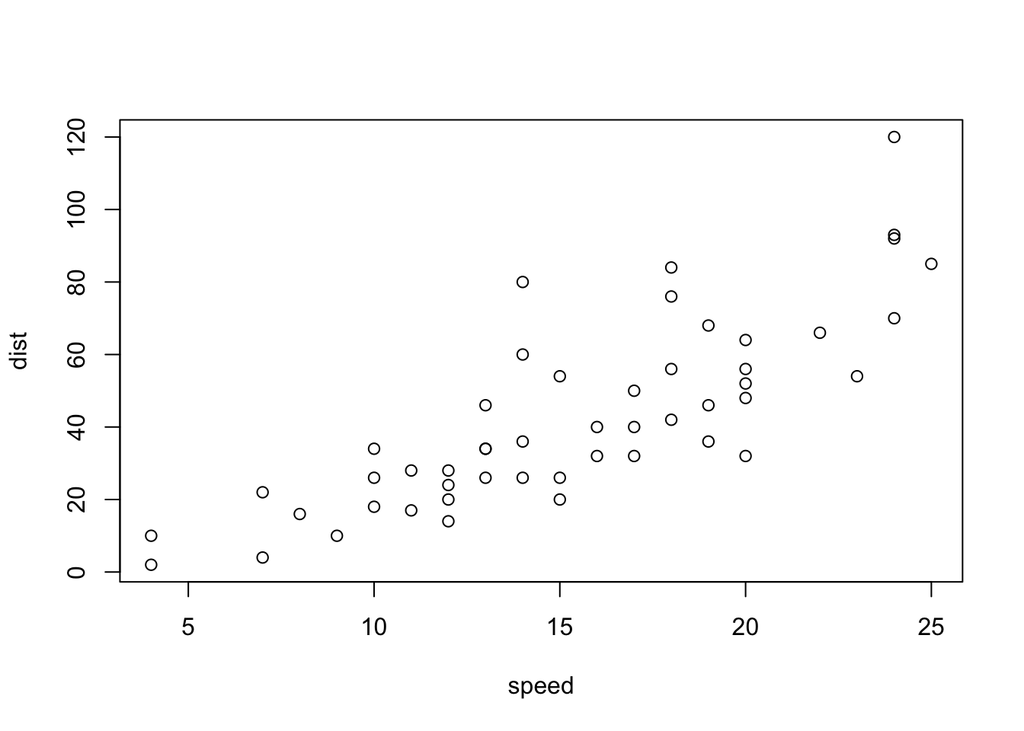

```r
plot(cars)
```

```r
x <- 7
y <- x*2
```

```r
x <- c(1,2,3)
x*2
```

```
## [1] 2 4 6
```

```r
mtcars$carb
```

```
##  [1] 4 4 1 1 2 1 4 2 2 4 4 3 3 3 4 4 4 1 2 1 1 2 2 4 2 1 2 2 4 6 8 2
```

```r
mtcars
```

|  | mpg | cyl | disp | hp | drat | wt | qsec | vs | am | gear | carb |
| --- | --- | --- | --- | --- | --- | --- | --- | --- | --- | --- | --- |
| Mazda RX4 | 21.0 | 6 | 160.0 | 110 | 3.90 | 2.620 | 16.46 | 0 | 1 | 4 | 4 |
| Mazda RX4 Wag | 21.0 | 6 | 160.0 | 110 | 3.90 | 2.875 | 17.02 | 0 | 1 | 4 | 4 |
| Datsun 710 | 22.8 | 4 | 108.0 | 93 | 3.85 | 2.320 | 18.61 | 1 | 1 | 4 | 1 |
| Hornet 4 Drive | 21.4 | 6 | 258.0 | 110 | 3.08 | 3.215 | 19.44 | 1 | 0 | 3 | 1 |
| Hornet Sportabout | 18.7 | 8 | 360.0 | 175 | 3.15 | 3.440 | 17.02 | 0 | 0 | 3 | 2 |
| Valiant | 18.1 | 6 | 225.0 | 105 | 2.76 | 3.460 | 20.22 | 1 | 0 | 3 | 1 |
| Duster 360 | 14.3 | 8 | 360.0 | 245 | 3.21 | 3.570 | 15.84 | 0 | 0 | 3 | 4 |
| Merc 240D | 24.4 | 4 | 146.7 | 62 | 3.69 | 3.190 | 20.00 | 1 | 0 | 4 | 2 |
| Merc 230 | 22.8 | 4 | 140.8 | 95 | 3.92 | 3.150 | 22.90 | 1 | 0 | 4 | 2 |
| Merc 280 | 19.2 | 6 | 167.6 | 123 | 3.92 | 3.440 | 18.30 | 1 | 0 | 4 | 4 |

[output cut: 22 more lines]

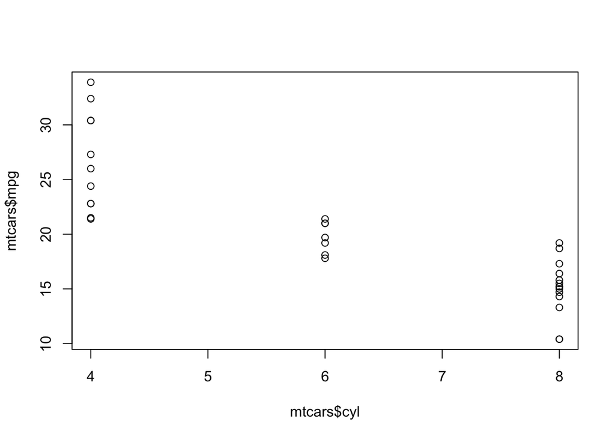

```r
plot(mtcars$cyl,mtcars$mpg)
```

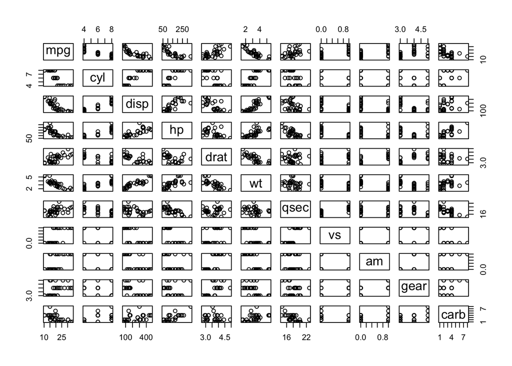

```r
plot(mtcars)
```

```r
?mtcars
```

## Session 3

```r
library(readr)
BX_Books <- read_delim("data/Archiv/BX-Books.csv",
    delim = ";", escape_double = FALSE, col_types = cols(`Year-Of-Publication` = col_integer(),
        `Image-URL-S` = col_skip(), `Image-URL-M` = col_skip(),
        `Image-URL-L` = col_skip()), trim_ws = TRUE)
library(tidyverse)
BX_Books %>%
  group_by(Publisher) %>%
  summarise(AnzahlBuecherProPublisher = n()) %>%
  arrange(desc(AnzahlBuecherProPublisher))
```

| Publisher | AnzahlBuecherProPublisher |
| --- | --- |
| Harlequin | 7526 |
| Silhouette | 4208 |
| Pocket | 3899 |
| Ballantine Books | 3776 |
| Bantam Books | 3631 |
| Scholastic | 3153 |
| Simon &amp; Schuster | 2964 |
| Penguin Books | 2838 |
| Berkley Publishing Group | 2769 |
| Warner Books | 2726 |

[output cut: 9990 more lines]

```r
BX_Books %>%
  group_by(`Year-Of-Publication`) %>%
  summarise(AnzahlBuecherProJahr = n()) %>%
  arrange(desc(AnzahlBuecherProJahr))
```

| Year-Of-Publication | AnzahlBuecherProJahr |
| --- | --- |
| 2002 | 17582 |
| 1999 | 17398 |
| 2001 | 17319 |
| 2000 | 17188 |
| 1998 | 15730 |
| 1997 | 14839 |
| 2003 | 14324 |
| 1996 | 13988 |
| 1995 | 13519 |
| 1994 | 11755 |

[output cut: 107 more lines]

```r
BX_Books %>%
  group_by(Publisher, `Book-Author`) %>%
  summarise(BuecherProPublisher = n()) %>%
  arrange(desc(BuecherProPublisher))
```

```
## `summarise()` has regrouped the output.
## ℹ Summaries were computed grouped by Publisher and Book-Author.
## ℹ Output is grouped by Publisher.
## ℹ Use `summarise(.groups = "drop_last")` to silence this message.
## ℹ Use `summarise(.by = c(Publisher, Book-Author))` for per-operation grouping
##   (`?dplyr::dplyr_by`) instead.
```

| Publisher | Book-Author | BuecherProPublisher |
| --- | --- | --- |
| Scholastic | Ann M. Martin | 270 |
| Sweet Valley | Francine Pascal | 219 |
| Silhouette | Nora Roberts | 150 |
| Gold Eagle | Don Pendleton | 146 |
| Jove Books | Barbara Cartland | 146 |
| Simon Pulse | Carolyn Keene | 132 |
| Aladdin | Carolyn Keene | 121 |
| Golden Books | Golden Books | 120 |
| Scholastic | R. L. Stine | 118 |
| Harlequin | Betty Neels | 105 |

[output cut: 9990 more lines]

```r
BX_Books %>%
  select(Publisher, `Book-Author`, `Year-Of-Publication`) %>%
  filter(`Year-Of-Publication` >= 1900) %>%
  arrange(`Year-Of-Publication`)
```

| Publisher | Book-Author | Year-Of-Publication |
| --- | --- | --- |
| Random House | Rachel Abramowitz | 1900 |
| Graphic Arts Center Pub Co | Ted Schredd | 1900 |
| E P Dutton | David J. Pelzer | 1900 |
| Fireside | S.J. Perelman | 1901 |
| Simon &amp; Schuster | Nikos Kazantzakis | 1901 |
| Simon &amp; Schuster | Bertrand Russell Russell | 1901 |
| Touchstone | James Thurber | 1901 |
| Simon &amp; Schuster | Dorothy Carnegie | 1901 |
| Fireside | Leonard Bernstein | 1901 |
| Simon &amp; Schuster | Jd Hersey | 1901 |

[output cut: 9990 more lines]

```r
BX_Books %>%
  group_by(`Book-Author`) %>%
  mutate(NumberOfBooks = n())
```

| ISBN | Book-Title | Book-Author | Year-Of-Publication | Publisher | NumberOfBooks |
| --- | --- | --- | --- | --- | --- |
| 0195153448 | Classical Mythology | Mark P. O. Morford | 2002 | Oxford University Press | 2 |
| 0002005018 | Clara Callan | Richard Bruce Wright | 2001 | HarperFlamingo Canada | 2 |
| 0060973129 | Decision in Normandy | Carlo D'Este | 1991 | HarperPerennial | 3 |
| 0374157065 | Flu: The Story of the Great Influenza Pandemic of 1918 and the Search for the Virus That Caused It | Gina Bari Kolata | 1999 | Farrar Straus Giroux | 2 |
| 0393045218 | The Mummies of Urumchi | E. J. W. Barber | 1999 | W. W. Norton &amp; Company | 1 |
| 0399135782 | The Kitchen God's Wife | Amy Tan | 1991 | Putnam Pub Group | 49 |
| 0425176428 | What If?: The World's Foremost Military Historians Imagine What Might Have Been | Robert Cowley | 2000 | Berkley Publishing Group | 5 |
| 0671870432 | PLEADING GUILTY | Scott Turow | 1993 | Audioworks | 37 |
| 0679425608 | Under the Black Flag: The Romance and the Reality of Life Among the Pirates | David Cordingly | 1996 | Random House | 3 |
| 074322678X | Where You'll Find Me: And Other Stories | Ann Beattie | 2002 | Scribner | 24 |

[output cut: 9990 more lines]

```r
library(readr)
BX_Users <- read_delim("data/Archiv/BX-Users.csv",
    delim = ";", escape_double = FALSE, col_types = cols(Age = col_integer()),
    trim_ws = TRUE)
summary(BX_Users)
```

```
##     User-ID         Location              Age
##  Min.   :     1   Length:246666      Min.   :  0.00
##  1st Qu.: 78167   Class :character   1st Qu.: 24.00
##  Median :142566   Mode  :character   Median : 32.00
##  Mean   :144244                      Mean   : 34.67
##  3rd Qu.:215800                      3rd Qu.: 44.00
##  Max.   :278858                      Max.   :244.00
##                                      NA's   :97797
```

Wichtige Beobachtungen aus dem Summary: 246.666 Nutzer, mittleres Alter 34.67 Jahre (Median: 32). Aber: das **Maximum liegt bei 244 Jahren** — ein klares Datenproblem, das bereinigt werden muss. Außerdem fehlen bei 97.797 Nutzern (~40%) die Altersangaben (NAs). Das ist eine typische Herausforderung bei realen Datensätzen.

```r
BX_Book_Ratings <- read_delim("data/Archiv/BX-Book-Ratings.csv",
    delim = ";", escape_double = FALSE, col_types = cols(`Book-Rating` = col_integer()),
    trim_ws = TRUE)
```

# Ein Histogramm erstellen

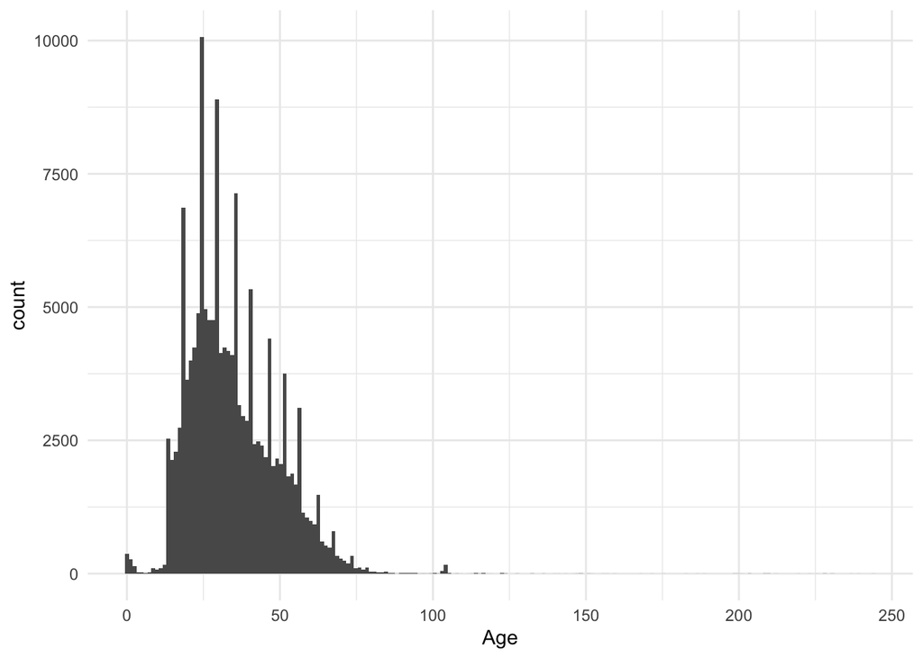

```r
BX_Users %>%
  filter(!is.na(Age)) %>%
  ggplot(., aes(x=Age)) +
  geom_histogram(bins = 200) +
  theme_minimal()
```

```r
BX_Users %>%
  group_by(Age) %>%
  summarise(n = n())
```

| Age | n |
| --- | --- |
| 0 | 368 |
| 1 | 262 |
| 2 | 100 |
| 3 | 38 |
| 4 | 20 |
| 5 | 22 |
| 6 | 16 |
| 7 | 23 |
| 8 | 48 |
| 9 | 57 |

[output cut: 149 more lines]

# Daten zusammenführen

```r
books <- BX_Books %>%
  full_join(BX_Book_Ratings) %>%
  full_join(BX_Users)
```

```
## Warning in full_join(., BX_Book_Ratings): Detected an unexpected many-to-many relationship between `x` and `y`.
## ℹ Row 2 of `x` matches multiple rows in `y`.
## ℹ Row 194306 of `y` matches multiple rows in `x`.
## ℹ If a many-to-many relationship is expected, set `relationship =
##   "many-to-many"` to silence this warning.
```

Der Join produziert eine **many-to-many-Warnung**: Ein Buch kann mehrere Bewertungen haben, und ein Nutzer kann mehrere Bücher bewertet haben — das ist hier gewollt. R warnt uns trotzdem, weil solche Joins schnell zu ungewollten Zeilen-Explosionen führen können. Immer prüfen, ob die Zeilenzahl danach sinnvoll ist!

# Sitzung 5: Streuungsmaße & Visualisierung

## Streuungsmaße der Buchbewertungen

```r
books |>
  summarise(Durchschnitt = mean(`Book-Rating`, na.rm = TRUE))
```

| Durchschnitt |
| --- |
| 2.694286 |

```r
books |>
  summarise(
    Spannweite = max(`Book-Rating`, na.rm = TRUE) - min(`Book-Rating`, na.rm = TRUE),
    IQR        = IQR(`Book-Rating`, na.rm = TRUE),
    Varianz    = var(`Book-Rating`, na.rm = TRUE),
    SD         = sd(`Book-Rating`, na.rm = TRUE)
  )
```

| Spannweite | IQR | Varianz | SD |
| --- | --- | --- | --- |
| 10 | 7 | 14.32919 | 3.785391 |

```r
cars |>
  summarise(
    Durchschnitt = mean(speed),
    SD = sd(speed)
  )
```

| Durchschnitt | SD |
| --- | --- |
| 15.4 | 5.287644 |

## Streuung nach Altersgruppe

```r
books |>
  filter(!is.na(Age)) |>
  mutate(Altersgruppe = cut(Age,
    breaks = c(0, 20, 30, 40, 60, 100),
    labels = c("bis 20", "21–30", "31–40", "41–60", "über 60"))) |>
  group_by(Altersgruppe) |>
  summarise(
    SD         = sd(`Book-Rating`, na.rm = TRUE),
    IQR        = IQR(`Book-Rating`, na.rm = TRUE),
    Mittelwert = mean(`Book-Rating`, na.rm = TRUE)
  )
```

| Altersgruppe | SD | IQR | Mittelwert |
| --- | --- | --- | --- |
| bis 20 | 4.041058 | 8 | 3.574222 |
| 21–30 | 3.848044 | 7 | 2.758578 |
| 31–40 | 3.803400 | 7 | 2.713556 |
| 41–60 | 3.805163 | 7 | 2.623532 |
| über 60 | 3.336149 | 0 | 1.810020 |
| NA | 3.360159 | 0 | 1.843750 |

## Histogramm der Buchbewertungen

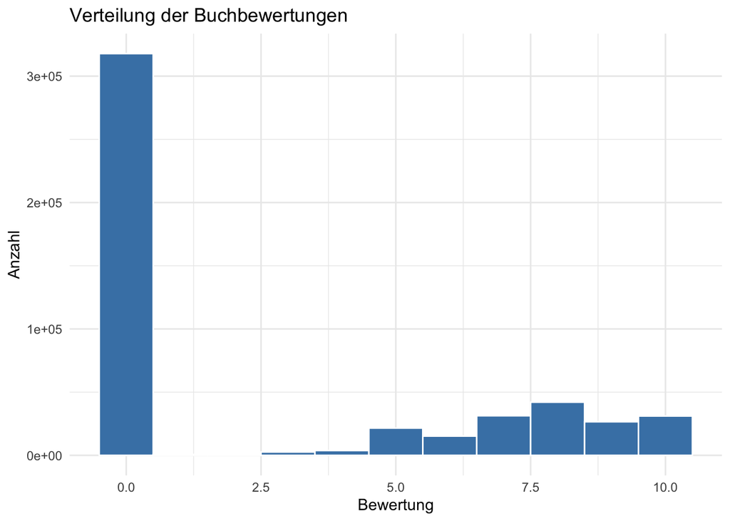

```r
books |>
  ggplot(aes(x = `Book-Rating`)) +
  geom_histogram(binwidth = 1, fill = "steelblue", color = "white") +
  labs(title = "Verteilung der Buchbewertungen",
       x = "Bewertung", y = "Anzahl") +
  theme_minimal()
```

## Nur echte Bewertungen (Book-Rating > 0)

```r
books |>
  filter(`Book-Rating` > 0) |>
  summarise(
    Spannweite = max(`Book-Rating`, na.rm = TRUE) - min(`Book-Rating`, na.rm = TRUE),
    IQR        = IQR(`Book-Rating`, na.rm = TRUE),
    Varianz    = var(`Book-Rating`, na.rm = TRUE),
    SD         = sd(`Book-Rating`, na.rm = TRUE)
  )
```

| Spannweite | IQR | Varianz | SD |
| --- | --- | --- | --- |
| 9 | 3 | 3.431309 | 1.852379 |

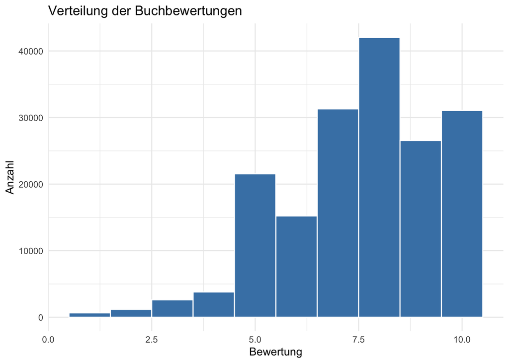

```r
books |>
  filter(`Book-Rating` > 0) |>
  ggplot(aes(x = `Book-Rating`)) +
  geom_histogram(binwidth = 1, fill = "steelblue", color = "white") +
  labs(title = "Verteilung der Buchbewertungen",
       x = "Bewertung", y = "Anzahl") +
  theme_minimal()
```

## Violin + Boxplot nach Altersgruppe

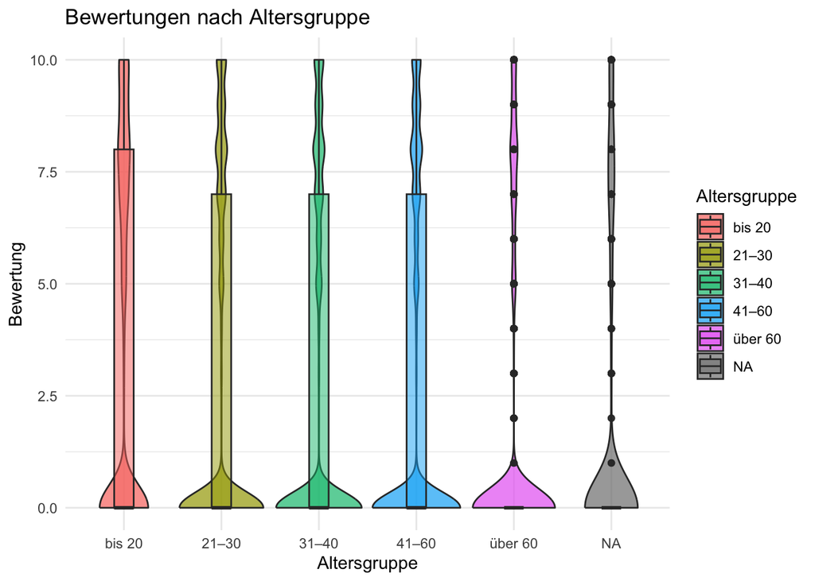

```r
books |>
  filter(!is.na(Age)) |>
  #filter(`Book-Rating` > 0) |>
  mutate(Altersgruppe = cut(Age,
    breaks = c(0, 20, 30, 40, 60, 100),
    labels = c("bis 20", "21–30", "31–40", "41–60", "über 60"))) |>
  ggplot(aes(x = Altersgruppe, y = `Book-Rating`, fill = Altersgruppe)) +
  geom_violin(alpha = 0.7) +
  geom_boxplot(width = 0.2, alpha = 0.5) +
  labs(title = "Bewertungen nach Altersgruppe",
       x = "Altersgruppe", y = "Bewertung") +
  theme_minimal()
```

## Density Plot: Bimodale Verteilung (Old Faithful Geysir)

Der Mittelwert der Wartezeit liegt bei ~71 Minuten — aber schau Dir die Verteilung an:

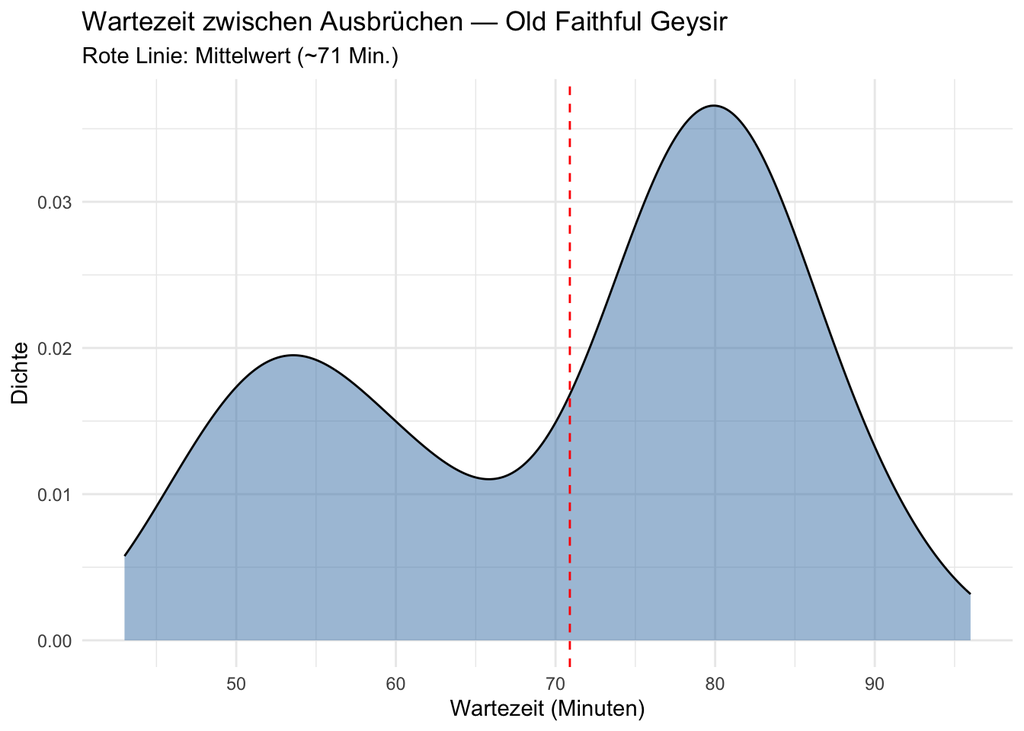

```r
faithful |>
  ggplot(aes(x = waiting)) +
  geom_density(fill = "steelblue", alpha = 0.5) +
  geom_vline(aes(xintercept = mean(waiting)),
             color = "red", linetype = "dashed") +
  labs(title = "Wartezeit zwischen Ausbrüchen — Old Faithful Geysir",
       subtitle = "Rote Linie: Mittelwert (~71 Min.)",
       x = "Wartezeit (Minuten)", y = "Dichte") +
  theme_minimal()
```

## Density Plot der Buchbewertungen

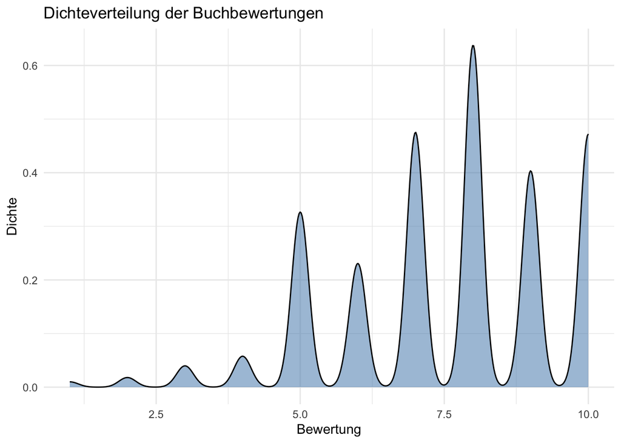

```r
books |>
  filter(`Book-Rating` > 0) |>
  ggplot(aes(x = `Book-Rating`)) +
  geom_density(fill = "steelblue", alpha = 0.5) +
  labs(title = "Dichteverteilung der Buchbewertungen",
       x = "Bewertung", y = "Dichte") +
  theme_minimal()
```

## Density Plot: Altersgruppen im Vergleich

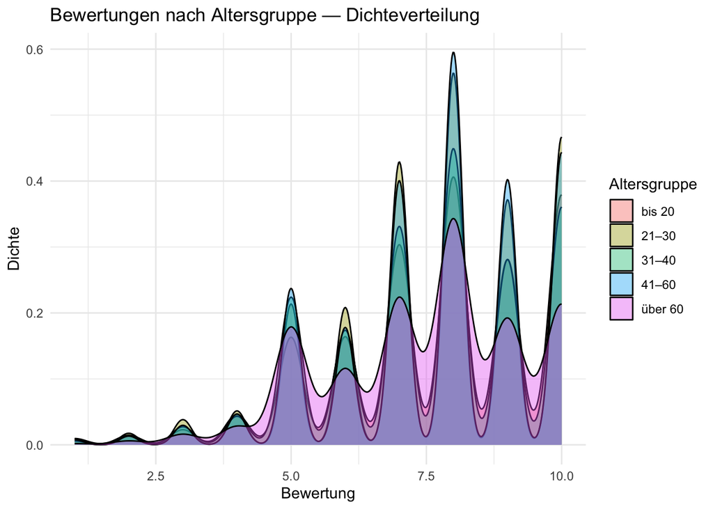

```r
books |>
  filter(Age > 5, Age <= 100, `Book-Rating` > 0) |>
  mutate(Altersgruppe = cut(Age,
    breaks = c(5, 20, 30, 40, 60, 100),
    labels = c("bis 20", "21–30", "31–40", "41–60", "über 60"))) |>
  ggplot(aes(x = `Book-Rating`, fill = Altersgruppe)) +
  geom_density(alpha = 0.4) +
  labs(title = "Bewertungen nach Altersgruppe — Dichteverteilung",
       x = "Bewertung", y = "Dichte") +
  theme_minimal()
```

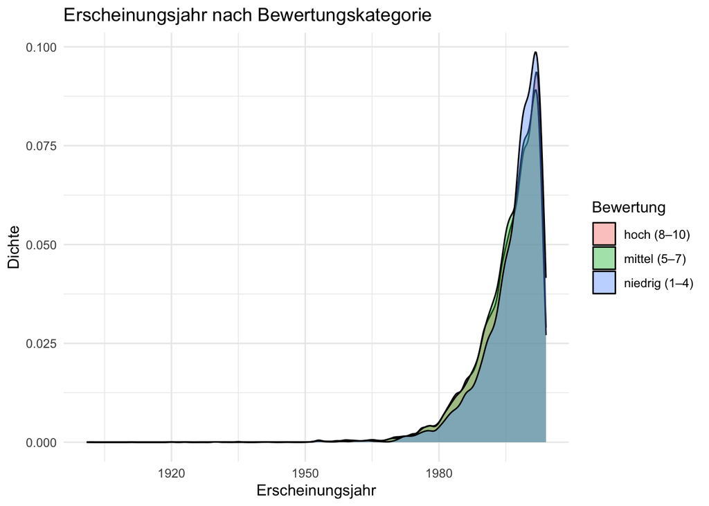

```r
books |>
  filter(`Book-Rating` > 0, `Year-Of-Publication` > 1900, `Year-Of-Publication` <= 2004) |>
  mutate(Bewertung = case_when(
    `Book-Rating` <= 4  ~ "niedrig (1–4)",
    `Book-Rating` <= 7  ~ "mittel (5–7)",
    `Book-Rating` >= 8  ~ "hoch (8–10)"
  )) |>
  ggplot(aes(x = `Year-Of-Publication`, fill = Bewertung)) +
  geom_density(alpha = 0.4) +
  labs(title = "Erscheinungsjahr nach Bewertungskategorie",
       x = "Erscheinungsjahr", y = "Dichte") +
  theme_minimal()
```

```r
cor.test(cars$speed, cars$dist)
```

```
##
##  Pearson's product-moment correlation
##
## data:  cars$speed and cars$dist
## t = 9.464, df = 48, p-value = 1.49e-12
## alternative hypothesis: true correlation is not equal to 0
## 95 percent confidence interval:
##  0.6816422 0.8862036
## sample estimates:
##       cor
## 0.8068949
```

**Ergebnis:** r = 0.807, p < 1.49e-12, 95%-KI [0.68, 0.89]. Starke positive Korrelation: je schneller das Auto fährt, desto länger der Bremsweg — das macht physikalisch Sinn. Hier ist Korrelation tatsächlich kausal interpretierbar, weil wir den Mechanismus kennen. Das ist aber die Ausnahme, nicht die Regel.

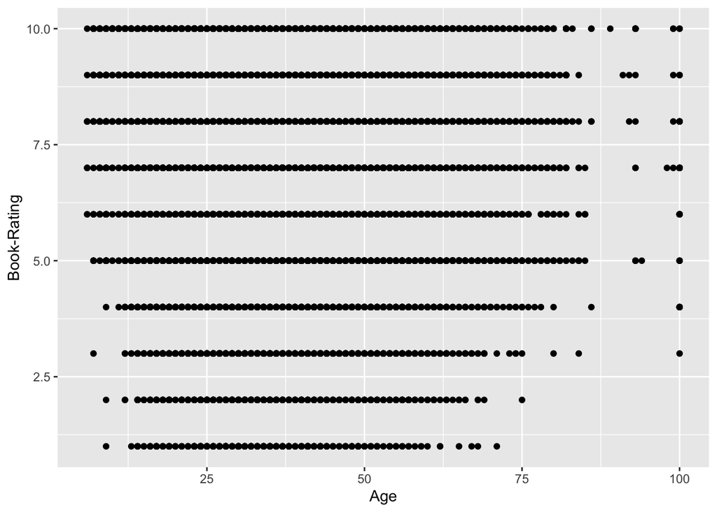

```r
books %>%
  filter(Age > 5) %>%
  filter(`Book-Rating` > 0) %>%
  filter(Age < 101) %>%
  ggplot(., aes(x = Age, y = `Book-Rating`)) +
  geom_point()
```

```r
cor.test(books$Age, books$`Book-Rating`)
```

```
##
##  Pearson's product-moment correlation
##
## data:  books$Age and books$`Book-Rating`
## t = -30.592, df = 316668, p-value < 2.2e-16
## alternative hypothesis: true correlation is not equal to 0
## 95 percent confidence interval:
##  -0.05775489 -0.05080956
## sample estimates:
##         cor
## -0.05428288
```

**Ergebnis:** r = -0.054, p < 2.2e-16. Wieder dasselbe Muster wie bei Chi-Quadrat und ANOVA: hochsignifikant, aber praktisch bedeutungslos. Eine Korrelation von -0.054 erklärt weniger als 0.3% der Varianz (r² = 0.003). Ältere Nutzer bewerten also minimal schlechter — aber dieser Effekt ist im Alltag irrelevant. Mit n > 300.000 wird fast alles signifikant.

# Sitzung 7: Inferenzstatistik — t-Test

## Einstichproben-t-Test: Ist der Würfel fair?

Wir simulieren 60 Würfelwürfe und testen, ob der Mittelwert signifikant von 3.5 abweicht (Erwartungswert eines fairen Würfels).

```r
set.seed(422)
würfe <- sample(1:6, 60, replace = TRUE)
mean(würfe)
```

```
## [1] 3.433333
```

```r
t.test(würfe, mu = 3.5)
```

```
##
##  One Sample t-test
##
## data:  würfe
## t = -0.29027, df = 59, p-value = 0.7726
## alternative hypothesis: true mean is not equal to 3.5
## 95 percent confidence interval:
##  2.973759 3.892907
## sample estimates:
## mean of x
##  3.433333
```

**Ergebnis:** t = -0.29, df = 59, p = 0.77. Das 95%-Konfidenzintervall [2.97, 3.89] enthält den Wert 3.5 — kein Hinweis darauf, dass der Würfel gezinkt ist. Wir behalten H₀ bei.

Frage: Gibt es einen Unterschied in den Buchbewertungen zwischen zwei Altersgruppen?

```r
gruppe_jung <- books |>
  filter(`Book-Rating` > 0, Age >= 18, Age <= 30) |>
  pull(`Book-Rating`)

gruppe_aelter <- books |>
  filter(`Book-Rating` > 0, Age >= 45, Age <= 60) |>
  pull(`Book-Rating`)

t.test(gruppe_jung, gruppe_aelter)
```

```
##
##  Welch Two Sample t-test
##
## data:  gruppe_jung and gruppe_aelter
## t = -4.7509, df = 49552, p-value = 2.031e-06
## alternative hypothesis: true difference in means is not equal to 0
## 95 percent confidence interval:
##  -0.10182859 -0.04234785
## sample estimates:
## mean of x mean of y
##  7.691269  7.763357
```

# Sitzung 7: Inferenzstatistik — Chi-Quadrat & ANOVA

## Chi-Quadrat-Test: Zusammenhang zwischen zwei kategorialen Variablen

Frage: Gibt es einen Zusammenhang zwischen Altersgruppe und Bewertungskategorie?

```r
library(tidyverse)

books_chi <- books |>
  filter(!is.na(Age), `Book-Rating` > 0, Age > 5, Age <= 100) |>
  mutate(
    Altersgruppe = cut(Age,
      breaks = c(5, 20, 30, 40, 60, 100),
      labels = c("bis 20", "21–30", "31–40", "41–60", "über 60")),
    Bewertungskategorie = cut(`Book-Rating`,
      breaks = c(0, 4, 7, 10),
      labels = c("niedrig (1–4)", "mittel (5–7)", "hoch (8–10)"))
  )

# Häufigkeitstabelle
tabelle <- table(books_chi$Altersgruppe, books_chi$Bewertungskategorie)
tabelle
```

```
##
##           niedrig (1–4) mittel (5–7) hoch (8–10)
##   bis 20            416         2826        4777
##   21–30            1611        11764       19384
##   31–40            1602        12838       19188
##   41–60            1312        11001       19436
##   über 60           164         1631        2358
```

```r
# Chi-Quadrat-Test
chisq.test(tabelle)
```

```
##
##  Pearson's Chi-squared test
##
## data:  tabelle
## X-squared = 155.95, df = 8, p-value < 2.2e-16
```

**Ergebnis:** χ²(8) = 155.95, p < 2.2e-16 → hochsignifikant. Es gibt einen statistisch nachweisbaren Zusammenhang zwischen Altersgruppe und Bewertungskategorie.

```r
# Effektstärke: Cramér's V
library(rstatix)
cramer_v(tabelle)
```

```
## [1] 0.02658714
```

**Aber:** Cramér’s V = 0.027 — das ist ein extrem kleiner Effekt. In der Häufigkeitstabelle sehen wir warum: In allen Altersgruppen dominieren hohe Bewertungen (8–10) klar. Das Muster ist nahezu identisch über alle Gruppen.

**Lehrmoment:** Wir haben über 100.000 Bewertungen — bei so großen Stichproben wird fast jeder noch so kleine Unterschied statistisch signifikant. Das p < 0.05 sagt uns nur, dass der Unterschied *existiert*, nicht dass er *wichtig* ist. Immer die Effektgröße berichten!

## ANOVA: Unterscheiden sich Bewertungen zwischen Altersgruppen?

Frage: Bewerten verschiedene Altersgruppen Bücher unterschiedlich? (3+ Gruppen → ANOVA statt t-Test)

```r
books_anova <- books |>
  filter(!is.na(Age), `Book-Rating` > 0, Age > 5, Age <= 100) |>
  mutate(Altersgruppe = cut(Age,
    breaks = c(5, 20, 30, 40, 60, 100),
    labels = c("bis 20", "21–30", "31–40", "41–60", "über 60")))

# Mittelwerte je Gruppe
books_anova |>
  group_by(Altersgruppe) |>
  summarise(
    Mittelwert = mean(`Book-Rating`, na.rm = TRUE),
    SD = sd(`Book-Rating`, na.rm = TRUE),
    n = n()
  )
```

| Altersgruppe | Mittelwert | SD | n |
| --- | --- | --- | --- |
| bis 20 | 7.701584 | 1.885963 | 8019 |
| 21–30 | 7.684087 | 1.843399 | 32759 |
| 31–40 | 7.587516 | 1.862025 | 33628 |
| 41–60 | 7.725409 | 1.795011 | 31749 |
| über 60 | 7.533831 | 1.789332 | 4153 |

```r
# ANOVA
ergebnis <- aov(`Book-Rating` ~ Altersgruppe, data = books_anova)
summary(ergebnis)
```

```
##                  Df Sum Sq Mean Sq F value Pr(>F)
## Altersgruppe      4    411  102.74   30.46 <2e-16 ***
## Residuals    110303 372012    3.37
## ---
## Signif. codes:  0 '***' 0.001 '**' 0.01 '*' 0.05 '.' 0.1 ' ' 1
```

**Ergebnis:** F(4, 110303) = 30.46, p < 2.2e-16 → hochsignifikant. Mindestens eine Altersgruppe bewertet Bücher anders als die anderen.

```r
# Post-hoc-Test: Welche Gruppen unterscheiden sich?
TukeyHSD(ergebnis)
```

```
##   Tukey multiple comparisons of means
##     95% family-wise confidence level
##
## Fit: aov(formula = `Book-Rating` ~ Altersgruppe, data = books_anova)
##
## $Altersgruppe
##                       diff         lwr         upr     p adj
## 21–30-bis 20   -0.01749692 -0.07991071  0.04491686 0.9406841
## 31–40-bis 20   -0.11406738 -0.17632238 -0.05181238 0.0000057
## 41–60-bis 20    0.02382494 -0.03878377  0.08643364 0.8377228
## über 60-bis 20 -0.16775277 -0.26352353 -0.07198202 0.0000175
## 31–40-21–30    -0.09657046 -0.13545874 -0.05768219 0.0000000
## 41–60-21–30     0.04132186  0.00186982  0.08077390 0.0347097
## über 60-21–30  -0.15025585 -0.23277039 -0.06774131 0.0000067
## 41–60-31–40     0.13789232  0.09869197  0.17709267 0.0000000
## über 60-31–40  -0.05368539 -0.13607989  0.02870911 0.3868483
## über 60-41–60  -0.19157771 -0.27423979 -0.10891563 0.0000000
```

**Lehrmoment (wieder):** Auch hier gilt — statistisch signifikant ≠ praktisch bedeutsam. Weniger als 0.2 Punkte Unterschied bei Bewertungen von 1–10 ist kaum relevant. Das ist der gleiche Effekt wie beim Chi-Quadrat-Test: große Stichprobe, winziger Effekt, trotzdem signifikant.

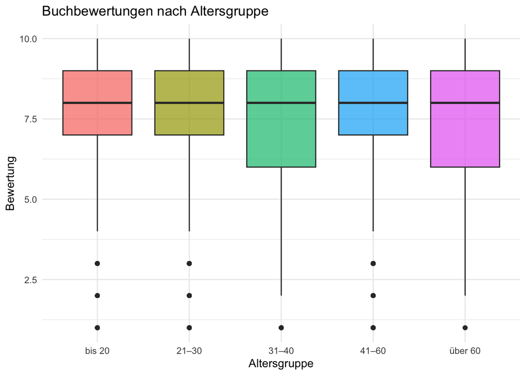

```r
# Visualisierung
books_anova |>
  ggplot(aes(x = Altersgruppe, y = `Book-Rating`, fill = Altersgruppe)) +
  geom_boxplot(alpha = 0.7) +
  labs(title = "Buchbewertungen nach Altersgruppe",
       x = "Altersgruppe", y = "Bewertung") +
  theme_minimal() +
  theme(legend.position = "none")
```

# Sitzung 8: Regression & logistische Regression

## Lineare Regression: Mieten vorhersagen

Wir starten mit dem Beispiel aus den Folien: Kann man aus der Wohnfläche die Miete vorhersagen?

```r
wohnungen <- data.frame(
  flaeche = c(30, 45, 60, 70, 80, 90, 100, 110, 120),
  miete = c(450, 600, 720, 850, 1000, 1150, 1250, 1400, 1550)
)

modell_lm <- lm(miete ~ flaeche, data = wohnungen)
summary(modell_lm)
```

```
##
## Call:
## lm(formula = miete ~ flaeche, data = wohnungen)
##
## Residuals:
##     Min      1Q  Median      3Q     Max
## -49.919 -17.280   9.039  15.602  51.123
##
## Coefficients:
##             Estimate Std. Error t value Pr(>|t|)
## (Intercept)  27.8356    36.0143   0.773    0.465
## flaeche      12.3681     0.4324  28.601 1.64e-08 ***
## ---
## Signif. codes:  0 '***' 0.001 '**' 0.01 '*' 0.05 '.' 0.1 ' ' 1
##
## Residual standard error: 36.69 on 7 degrees of freedom
## Multiple R-squared:  0.9915, Adjusted R-squared:  0.9903
## F-statistic:   818 on 1 and 7 DF,  p-value: 1.643e-08
```

**Ergebnis:** Pro zusätzlichem Quadratmeter steigt die Miete um ca. 12 €, das R² liegt nahe 1 — die Fläche erklärt fast die gesamte Varianz. So schöne Werte gibt es nur bei konstruierten Beispieldaten; echte Daten streuen deutlich mehr.

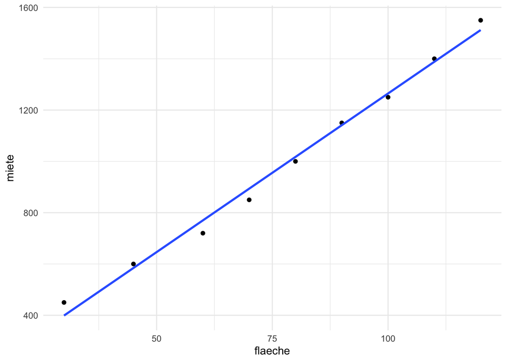

```r
ggplot(wohnungen, aes(x = flaeche, y = miete)) +
  geom_point() +
  geom_smooth(method = "lm", se = FALSE) +
  theme_minimal()
```

## Multiple Regression mit echten(eren) Daten

```r
Wohnungen_mit_Energieeffizienz <- read_csv("data/Wohnungen_mit_Energieeffizienz.csv")
modell_multi <- lm(miete ~ flaeche + saniert + energieeffizienz,
                   data = Wohnungen_mit_Energieeffizienz)
summary(modell_multi)
```

```
##
## Call:
## lm(formula = miete ~ flaeche + saniert + energieeffizienz, data = Wohnungen_mit_Energieeffizienz)
##
## Residuals:
##      Min       1Q   Median       3Q      Max
## -229.832  -58.979   -0.542   64.835  253.611
##
## Coefficients:
##                     Estimate Std. Error t value Pr(>|t|)
## (Intercept)         -48.9015    39.0540  -1.252 0.213622
## flaeche              12.2237     0.4369  27.975  < 2e-16 ***
## saniert             167.3439    19.0712   8.775 7.39e-14 ***
## energieeffizienzA+  -12.4862    29.3889  -0.425 0.671909
## energieeffizienzB   -90.1896    24.0386  -3.752 0.000304 ***
## energieeffizienzC  -152.3476    26.0785  -5.842 7.37e-08 ***
## ---
## Signif. codes:  0 '***' 0.001 '**' 0.01 '*' 0.05 '.' 0.1 ' ' 1
##
## Residual standard error: 93.31 on 94 degrees of freedom
## Multiple R-squared:  0.9151, Adjusted R-squared:  0.9106
## F-statistic: 202.6 on 5 and 94 DF,  p-value: < 2.2e-16
```

**Interpretation:** Jeder Koeffizient zeigt den Effekt *bei Konstanthaltung der anderen Variablen*. Sanierung und bessere Energieeffizienzklassen erhöhen die Miete zusätzlich zur Fläche.

## Logistische Regression: Überleben auf der Titanic

Bisher haben wir eine Zahl vorhergesagt (Miete in Euro). Oft ist die Zielvariable aber nur ja/nein: Wird ein Buch ausgeliehen? Ist eine E-Mail Spam? Hier: Überlebt ein Passagier den Untergang der Titanic?

```r
titanic <- read.csv2("data/titanic.csv")
```

### Warum keine Gerade?

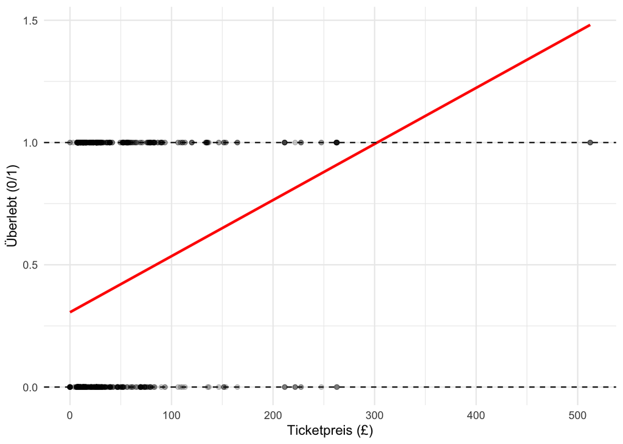

```r
ggplot(titanic, aes(x = fare, y = survived)) +
  geom_point(alpha = 0.2) +
  geom_smooth(method = "lm", se = FALSE, color = "red") +
  geom_hline(yintercept = c(0, 1), linetype = "dashed") +
  labs(x = "Ticketpreis (£)", y = "Überlebt (0/1)") +
  theme_minimal()
```

Die Gerade sagt beim teuersten Ticket (£512) eine “Überlebenswahrscheinlichkeit” von 1,48 vorher — 148 % gibt es nicht. Wir brauchen etwas, das immer zwischen 0 und 1 bleibt.

### Die S-Kurve

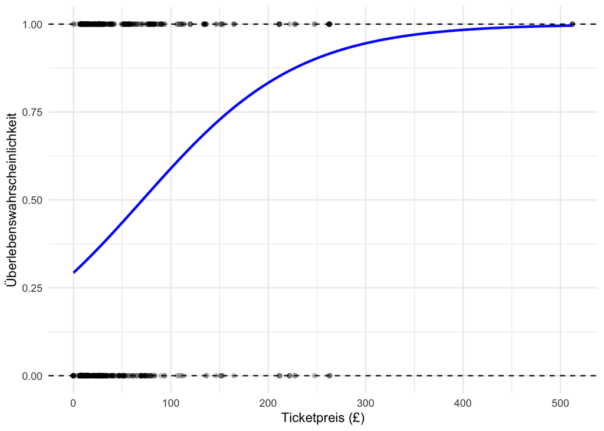

```r
ggplot(titanic, aes(x = fare, y = survived)) +
  geom_point(alpha = 0.2) +
  geom_smooth(method = "glm", method.args = list(family = "binomial"),
              se = FALSE, color = "blue") +
  geom_hline(yintercept = c(0, 1), linetype = "dashed") +
  labs(x = "Ticketpreis (£)", y = "Überlebenswahrscheinlichkeit") +
  theme_minimal()
```

### Das Modell

Aus `lm()` wird `glm()` plus `family = binomial` — sonst ändert sich fast nichts:

```r
modell_logit <- glm(survived ~ age + sex + factor(pclass),
                    family = binomial,
                    data = titanic)
summary(modell_logit)
```

```
##
## Call:
## glm(formula = survived ~ age + sex + factor(pclass), family = binomial,
##     data = titanic)
##
## Coefficients:
##                  Estimate Std. Error z value Pr(>|z|)
## (Intercept)      3.522074   0.326702  10.781  < 2e-16 ***
## age             -0.034393   0.006331  -5.433 5.56e-08 ***
## sexmale         -2.497845   0.166037 -15.044  < 2e-16 ***
## factor(pclass)2 -1.280570   0.225538  -5.678 1.36e-08 ***
## factor(pclass)3 -2.289661   0.225802 -10.140  < 2e-16 ***
## ---
## Signif. codes:  0 '***' 0.001 '**' 0.01 '*' 0.05 '.' 0.1 ' ' 1
##
## (Dispersion parameter for binomial family taken to be 1)
##
##     Null deviance: 1414.62  on 1045  degrees of freedom
## Residual deviance:  982.45  on 1041  degrees of freedom
##   (264 observations deleted due to missingness)
## AIC: 992.45
##
## Number of Fisher Scoring iterations: 4
```

**Interpretation über die Vorzeichen:** `sexmale` negativ → Männer überlebten seltener. `factor(pclass)2/3` negativ → je schlechter die Klasse, desto geringer die Überlebenschance. `age` negativ → Ältere überlebten seltener. “Frauen und Kinder zuerst” — die Daten bestätigen es.

### Konkrete Vorhersagen

```r
neue_passagiere <- data.frame(
  age = c(30, 30),
  sex = c("female", "male"),
  pclass = c(1, 3)
)

predict(modell_logit, newdata = neue_passagiere, type = "response")
```

```
##          1          2
## 0.92345739 0.09135279
```

**Ergebnis:** Eine 30-jährige Frau in der 1. Klasse hat laut Modell ca. 92 % Überlebenswahrscheinlichkeit, ein 30-jähriger Mann in der 3. Klasse ca. 9 %.

### Für Neugierige: Odds Ratios (Selbststudium)

Die Koeffizienten eines `glm()` sind sogenannte Log-Odds — schwer zu lesen. Mit `exp()` werden daraus **Odds Ratios**: Werte über 1 erhöhen die Chance, Werte unter 1 senken sie.

```r
exp(coef(modell_logit))
```

```
##     (Intercept)             age         sexmale factor(pclass)2 factor(pclass)3
##     33.85457044      0.96619149      0.08226211      0.27787894      0.10130084
```

**Lesebeispiel:** Das Odds Ratio für `sexmale` liegt bei ca. 0.08 — die Überlebens-*Chance* (Odds) eines Mannes betrug nur etwa 8 % der einer Frau (bei gleichem Alter und gleicher Klasse). Wichtig: Odds sind nicht dasselbe wie Wahrscheinlichkeiten — für konkrete Wahrscheinlichkeiten nutzen wir `predict(..., type = "response")` wie oben.

# Sitzung 8: Prinzipien der Datenvisualisierung

> “The greatest value of a picture is when it forces us to notice what we never expected to see.” (John Tukey)

Für einige Beispiele brauchen wir zusätzliche Packages — einmalig installieren:

```r
install.packages(c("titanic", "nycflights23", "reshape2",
                   "ggalluvial", "treemapify", "scales"))
```

```r
library(tidyverse)
```

## Redundant Coding

Nicht jeder kann Farben gleich gut unterscheiden (ca. 8 % der Männer haben eine Rot-Grün-Schwäche). Deshalb kodieren wir wichtige Unterscheidungen doppelt: hier Farbe **und** Form.

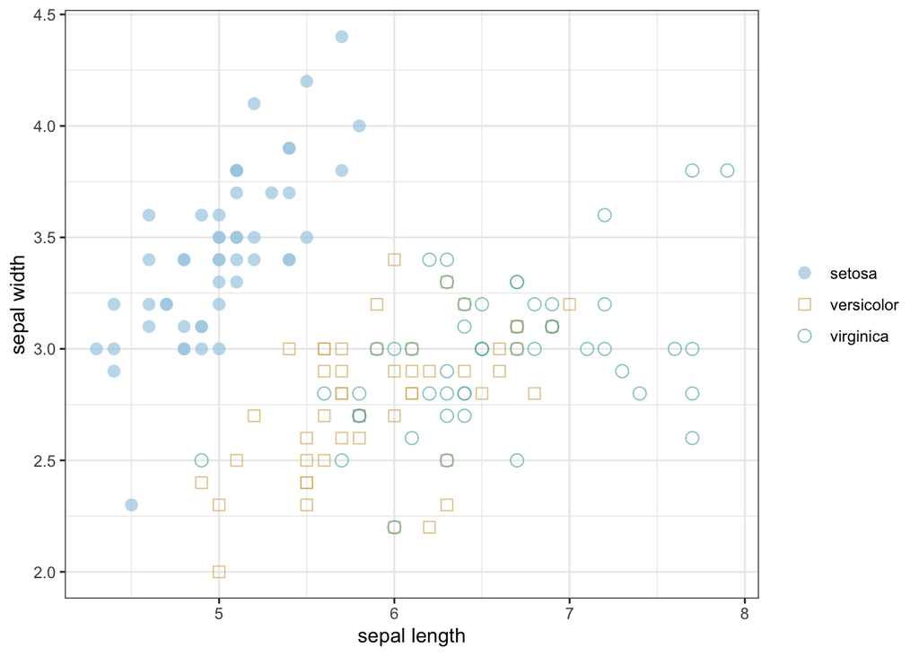

```r
ggplot(iris, aes(x = Sepal.Length, y = Sepal.Width,
                 color = Species, shape = Species)) +
  geom_point(size = 3, alpha = 0.7) +
  scale_color_manual(values = c("setosa" = "#a6cee3",
                                "virginica" = "#5ab4ac",
                                "versicolor" = "#d8b365")) +
  scale_shape_manual(values = c("setosa" = 16,
                                "virginica" = 21,
                                "versicolor" = 22)) +
  labs(x = "sepal length", y = "sepal width") +
  theme_bw() +
  theme(legend.title = element_blank())
```

## Weißer Space: Clutter entfernen, aber lesbar bleiben

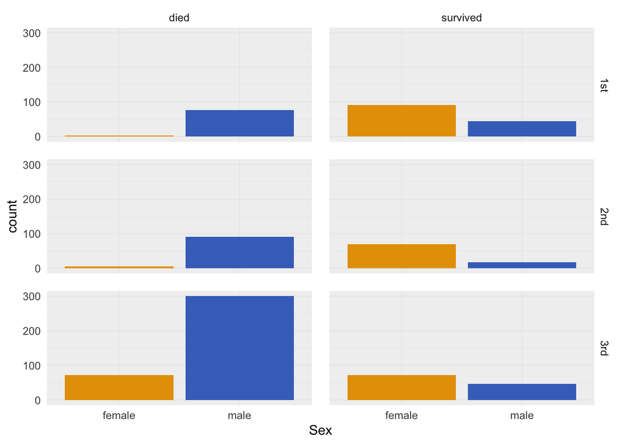

```r
library(titanic)
data("titanic_train")

titanic_data <- titanic_train %>%
  mutate(
    Sex = factor(Sex, levels = c("female", "male")),
    Survived = factor(ifelse(Survived == 1, "survived", "died")),
    Pclass = factor(Pclass, labels = c("1st", "2nd", "3rd"))
  ) %>%
  count(Pclass, Sex, Survived) %>%
  rename(count = n)

ggplot(titanic_data, aes(x = Sex, y = count, fill = Sex)) +
  geom_col() +
  facet_grid(Pclass ~ Survived) +
  scale_fill_manual(values = c("female" = "#E69F00", "male" = "#4472C4")) +
  theme_minimal() +
  theme(
    legend.position = "none",
    panel.spacing = unit(5, "mm"),
    panel.background = element_rect(fill = "#F1F1F1", color = NA),
    strip.background = element_rect(fill = "white", color = NA)
  )
```

## Highlighting

Wenn eine Aussage im Fokus steht, bekommt nur das relevante Element eine Signalfarbe — der Rest tritt in Grau zurück. Die Augen des Betrachters gehen sofort dorthin.

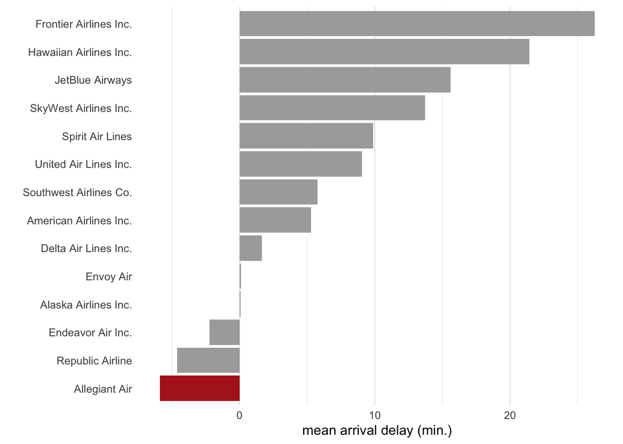

```r
library(nycflights23)

airline_delays <- flights %>%
  group_by(carrier) %>%
  summarise(mean_delay = mean(arr_delay, na.rm = TRUE)) %>%
  left_join(airlines, by = "carrier") %>%
  arrange(mean_delay)

farben <- ifelse(airline_delays$carrier == "G4", "#B22222", "#AAAAAA")

ggplot(airline_delays, aes(x = reorder(name, mean_delay), y = mean_delay)) +
  geom_col(fill = farben) +
  coord_flip() +
  labs(x = "", y = "mean arrival delay (min.)") +
  theme_minimal() +
  theme(
    panel.grid.major.y = element_blank(),
    panel.grid.minor.y = element_blank()
  )
```

## Diagrammtypen-Galerie

Welches Diagramm passt zu welcher Frage? Die folgenden Beispiele nutzen simulierte Daten — der Code ist bewusst kurz gehalten, damit Sie ihn als Vorlage für Ihre eigenen Daten verwenden können.

### Scatter Plot / Streudiagramm

Beziehung zwischen zwei kontinuierlichen Variablen; erkennt Muster, Cluster, Ausreißer.

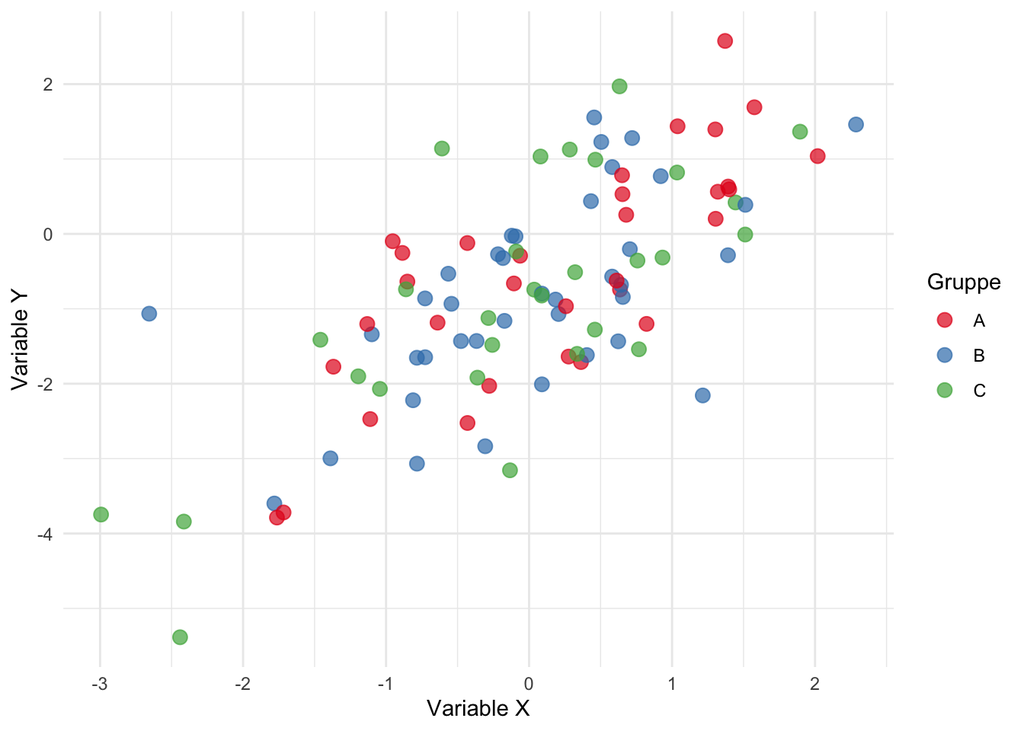

```r
set.seed(42)
scatter_data <- data.frame(x = rnorm(100), y = rnorm(100),
  gruppe = sample(LETTERS[1:3], 100, replace = TRUE))
scatter_data$y <- scatter_data$y + scatter_data$x - 0.7 + rnorm(100, 0, 0.5)

ggplot(scatter_data, aes(x = x, y = y, color = gruppe)) +
  geom_point(size = 3, alpha = 0.7) +
  scale_color_brewer(palette = "Set1") +
  theme_minimal() +
  labs(x = "Variable X", y = "Variable Y", color = "Gruppe")
```

### Korrelationsmatrix

Korrelationsstärke zwischen mehreren Variablen auf einen Blick — essentiell für explorative Datenanalyse.

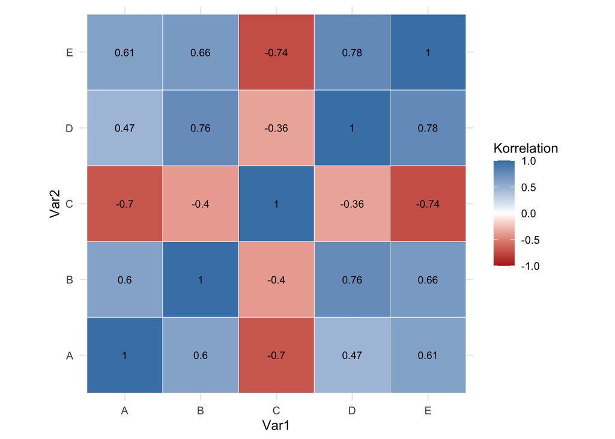

```r
library(reshape2)
set.seed(123)
sim_data <- data.frame(A = rnorm(100), B = rnorm(100), C = rnorm(100),
  D = rnorm(100), E = rnorm(100))
sim_data$B <- sim_data$B + sim_data$A - 0.7 + rnorm(100, 0, 0.5)
sim_data$C <- sim_data$C - sim_data$A - 0.4 + rnorm(100, 0, 0.5)
sim_data$D <- sim_data$D + sim_data$B - 0.6 + rnorm(100, 0, 0.5)
sim_data$E <- sim_data$E - sim_data$C - 0.5 + sim_data$D - 0.3 + rnorm(100, 0, 0.5)

cormat <- round(cor(sim_data), 2)
melted_cormat <- melt(cormat)

ggplot(melted_cormat, aes(x = Var1, y = Var2, fill = value)) +
  geom_tile(color = "white") +
  scale_fill_gradient2(low = "firebrick", high = "steelblue", mid = "white",
                       midpoint = 0, limit = c(-1, 1)) +
  geom_text(aes(label = round(value, 2)), color = "black", size = 3) +
  theme_minimal() + coord_equal() + labs(fill = "Korrelation")
```

### Sankey Diagram

Flüsse zwischen Kategorien; die Breite zeigt das Volumen.

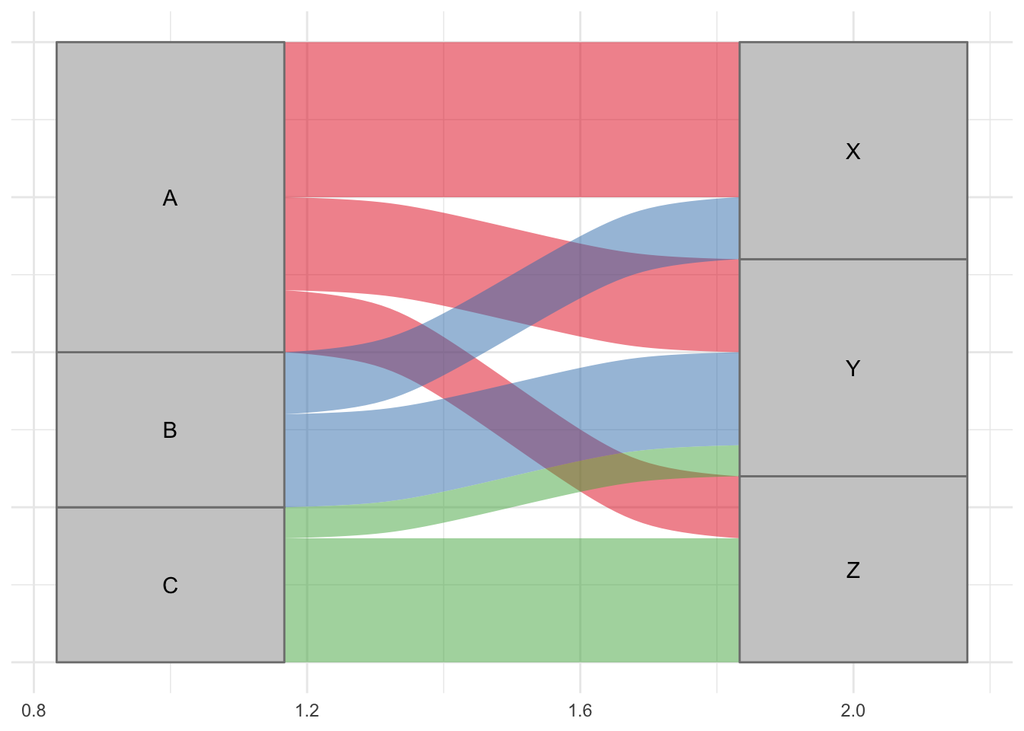

```r
library(ggalluvial)
sankey_data <- data.frame(
  Quelle = rep(c("A", "B", "C"), times = c(3, 2, 2)),
  Ziel = c("X", "Y", "Z", "X", "Y", "Y", "Z"),
  Wert = c(5, 3, 2, 2, 3, 1, 4))

ggplot(sankey_data, aes(axis1 = Quelle, axis2 = Ziel, y = Wert)) +
  geom_alluvium(aes(fill = Quelle), width = 1/3) +
  geom_stratum(width = 1/3, fill = "grey80", color = "grey50") +
  geom_text(stat = "stratum", aes(label = after_stat(stratum))) +
  scale_fill_brewer(palette = "Set1") +
  theme_minimal() + labs(x = NULL, y = NULL) +
  theme(legend.position = "none", axis.text.y = element_blank(),
        axis.ticks = element_blank())
```

### Horizontal Bar Chart

Ideal für Rankings und lange Kategorienamen.

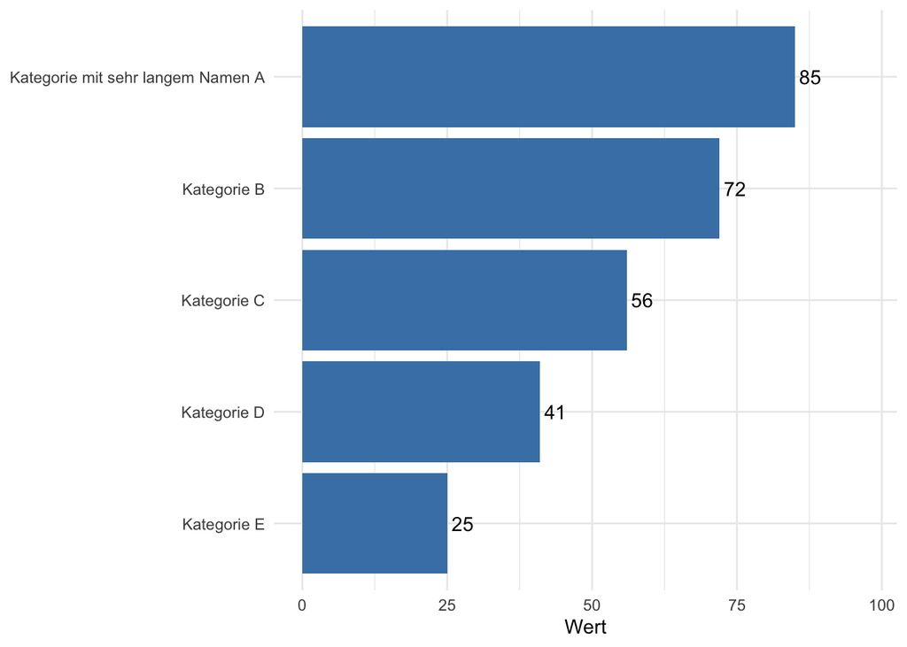

```r
hbar_data <- data.frame(
  kategorie = c("Kategorie mit sehr langem Namen A", "Kategorie B",
                "Kategorie C", "Kategorie D", "Kategorie E"),
  wert = c(85, 72, 56, 41, 25))

ggplot(hbar_data, aes(x = reorder(kategorie, wert), y = wert)) +
  geom_bar(stat = "identity", fill = "steelblue") +
  coord_flip() + theme_minimal() + labs(x = NULL, y = "Wert") +
  geom_text(aes(label = wert), hjust = -0.2) +
  ylim(0, max(hbar_data$wert) * 1.15)
```

### Column Chart

Vertikale Balken für wenige, klare Kategorien — Basislinie immer bei 0!

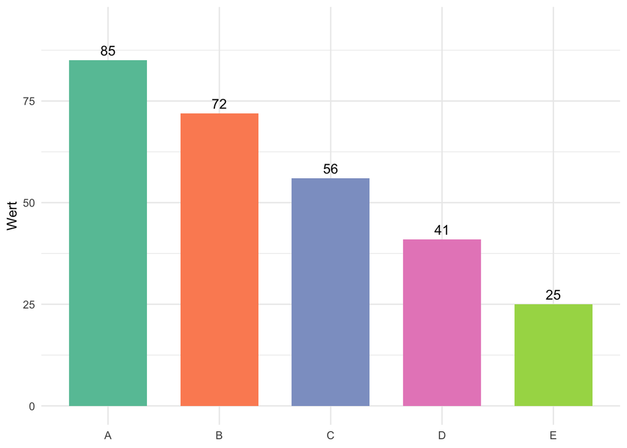

```r
column_data <- data.frame(
  kategorie = factor(c("A", "B", "C", "D", "E")),
  wert = c(85, 72, 56, 41, 25))

ggplot(column_data, aes(x = kategorie, y = wert, fill = kategorie)) +
  geom_bar(stat = "identity", width = 0.7) +
  scale_fill_brewer(palette = "Set2") + theme_minimal() +
  labs(x = NULL, y = "Wert") + theme(legend.position = "none") +
  geom_text(aes(label = wert), vjust = -0.5) +
  ylim(0, max(column_data$wert) * 1.1)
```

### Diverging Bars

Abweichungen in zwei Richtungen von einer zentralen Basislinie (z.B. positiv/negativ, Z-Scores).

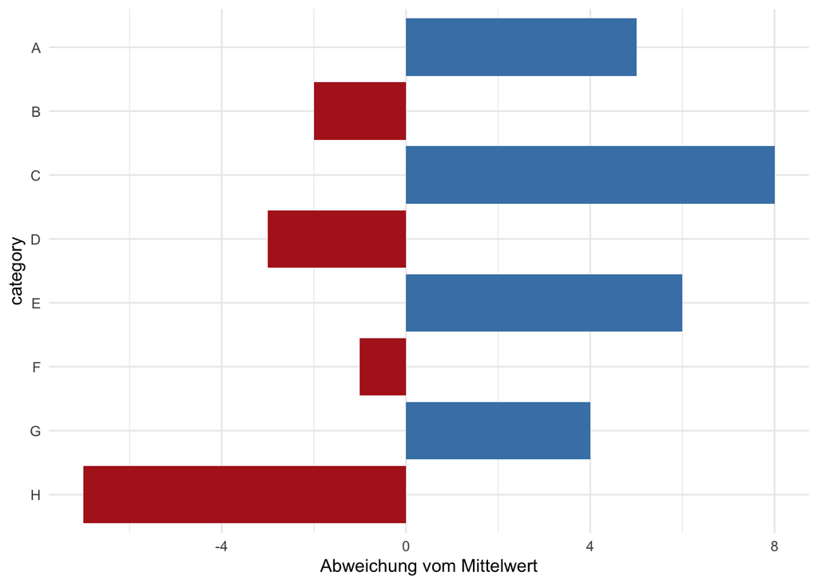

```r
diverging_data <- data.frame(
  category = factor(LETTERS[1:8], levels = LETTERS[8:1]),
  value = c(5, -2, 8, -3, 6, -1, 4, -7))

ggplot(diverging_data, aes(x = category, y = value, fill = value > 0)) +
  geom_bar(stat = "identity") +
  scale_fill_manual(values = c("firebrick", "steelblue"), guide = "none") +
  coord_flip() + theme_minimal() + labs(y = "Abweichung vom Mittelwert")
```

### Diverging Lollipop Chart

Elegantere Alternative zu Diverging Bars — weniger “Tinte”, gleiche Information.

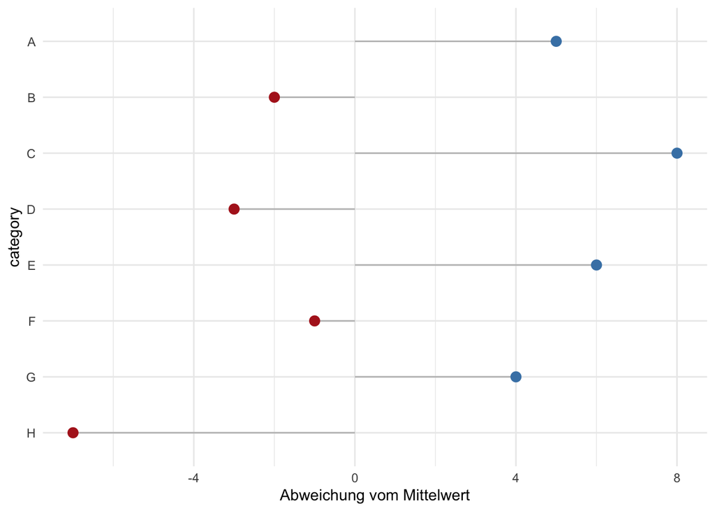

```r
lollipop_data <- data.frame(
  category = factor(LETTERS[1:8], levels = LETTERS[8:1]),
  value = c(5, -2, 8, -3, 6, -1, 4, -7))

ggplot(lollipop_data, aes(x = category, y = value, color = value > 0)) +
  geom_segment(aes(y = 0, x = category, yend = value, xend = category),
               color = "grey") +
  geom_point(size = 3) +
  scale_color_manual(values = c("firebrick", "steelblue"), guide = "none") +
  coord_flip() + theme_minimal() + labs(y = "Abweichung vom Mittelwert")
```

### Histogram

Verteilung numerischer Daten in Bins — hier mit zwei Modi (kennen wir vom Old-Faithful-Beispiel).

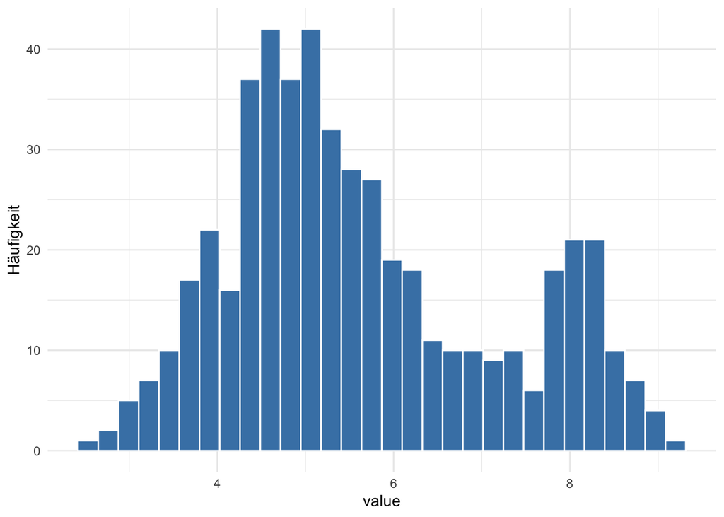

```r
set.seed(123)
hist_data <- data.frame(
  value = c(rnorm(400, mean = 5, sd = 1), rnorm(100, mean = 8, sd = 0.5)))

ggplot(hist_data, aes(x = value)) +
  geom_histogram(bins = 30, fill = "steelblue", color = "white") +
  theme_minimal() + labs(y = "Häufigkeit")
```

### Boxplots

Kompakter Kategorienvergleich: Median, Quartile, Ausreißer.

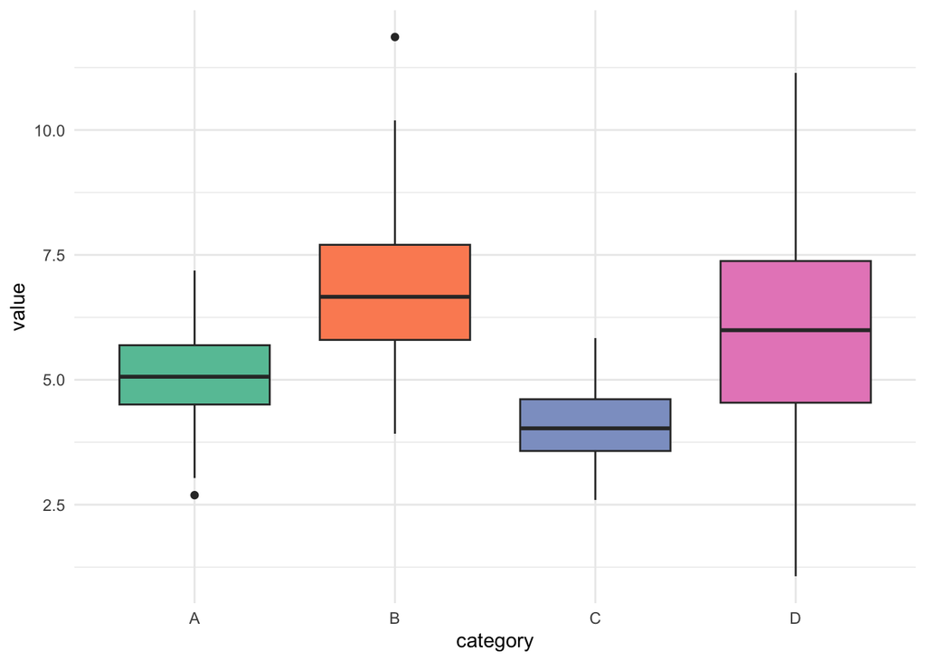

```r
set.seed(123)
box_data <- data.frame(
  category = rep(c("A", "B", "C", "D"), each = 100),
  value = c(rnorm(100, mean = 5, sd = 1), rnorm(100, mean = 7, sd = 1.5),
            rnorm(100, mean = 4, sd = 0.8), rnorm(100, mean = 6, sd = 2)))

ggplot(box_data, aes(x = category, y = value, fill = category)) +
  geom_boxplot() +
  scale_fill_brewer(palette = "Set2", guide = "none") + theme_minimal()
```

### Boxplot mit echten Daten: Verspätungen + Highlighting

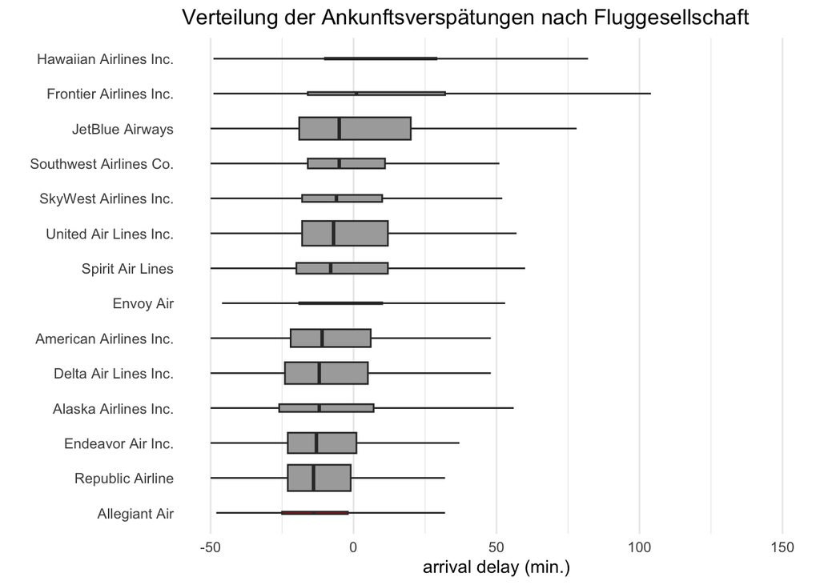

```r
delay_data <- flights %>%
  left_join(airlines, by = "carrier")

carrier_order <- delay_data %>%
  group_by(carrier, name) %>%
  summarise(median_delay = median(arr_delay, na.rm = TRUE), .groups = "drop") %>%
  arrange(median_delay)

delay_data$color <- ifelse(delay_data$carrier == "G4", "#B22222", "#AAAAAA")

ggplot(delay_data, aes(x = factor(name, levels = carrier_order$name),
                       y = arr_delay)) +
  geom_boxplot(aes(fill = color), outlier.shape = NA, varwidth = TRUE) +
  coord_flip() +
  scale_fill_identity() +
  scale_y_continuous(limits = c(-50, 150)) +
  labs(title = "Verteilung der Ankunftsverspätungen nach Fluggesellschaft",
       x = "", y = "arrival delay (min.)") +
  theme_minimal() +
  theme(panel.grid.major.y = element_blank(),
        panel.grid.minor.y = element_blank())
```

### Violin Plot + Boxplot

Zeigt zusätzlich die Form der Verteilung — Gruppe A ist bimodal, das sieht man im Boxplot allein nicht!

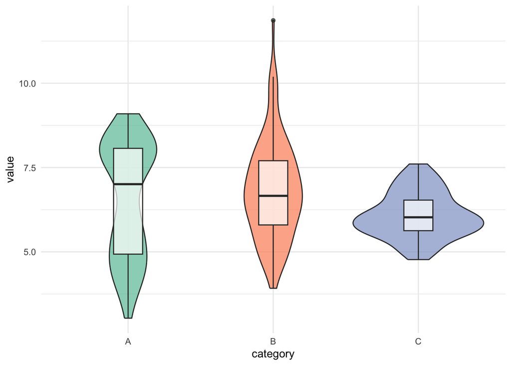

```r
set.seed(123)
violin_data <- data.frame(
  category = rep(c("A", "B", "C"), each = 100),
  value = c(c(rnorm(50, 5, 1), rnorm(50, 8, 0.5)),
            rnorm(100, 7, 1.5), rnorm(100, 6, 0.7)))

ggplot(violin_data, aes(x = category, y = value, fill = category)) +
  geom_violin(alpha = 0.7) +
  geom_boxplot(width = 0.2, fill = "white", alpha = 0.7) +
  scale_fill_brewer(palette = "Set2", guide = "none") + theme_minimal()
```

### Stacked Area Chart

Beiträge von Kategorien zur Gesamtsumme im Zeitverlauf.

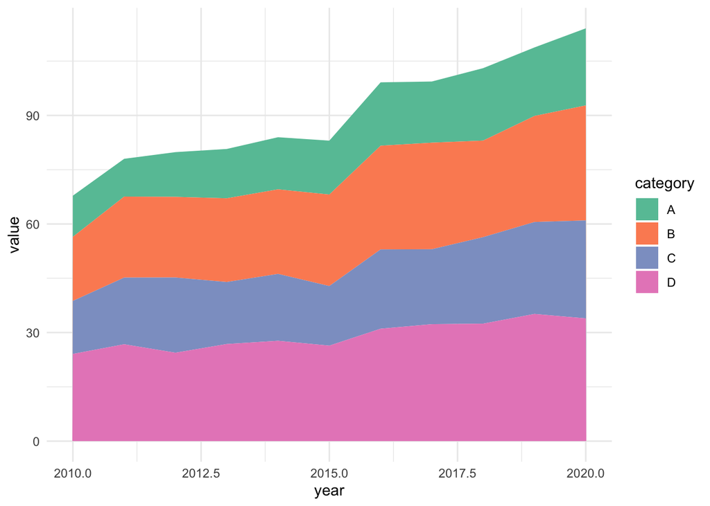

```r
set.seed(42)
years <- 2010:2020
area_data <- data.frame(
  year = rep(years, 4),
  category = rep(c("A", "B", "C", "D"), each = length(years)),
  value = c(10:20 + rnorm(11, 0, 1), 20:30 - rnorm(11, 0, 1),
            15:25 + rnorm(11, 0, 2), 25:35 + rnorm(11, 0, 1.5)))

ggplot(area_data, aes(x = year, y = value, fill = category)) +
  geom_area() + scale_fill_brewer(palette = "Set2") + theme_minimal()
```

### Stacked 100% Area Chart

Gleiche Daten, aber relative Anteile statt absoluter Werte — Fokus auf Zusammensetzung.

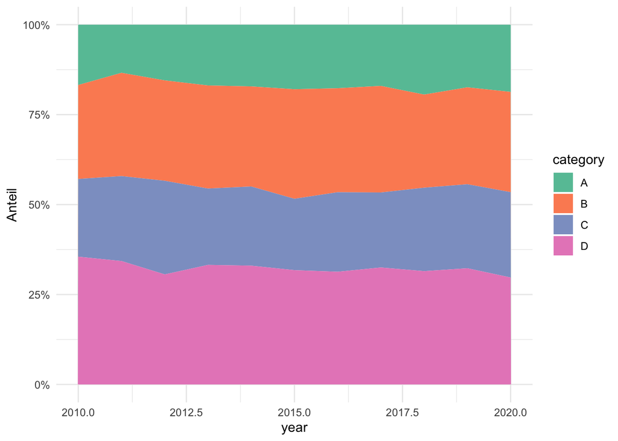

```r
ggplot(area_data, aes(x = year, y = value, fill = category)) +
  geom_area(position = "fill") +
  scale_y_continuous(labels = scales::percent) +
  scale_fill_brewer(palette = "Set2") + theme_minimal() + labs(y = "Anteil")
```

### Waterfall Diagram

Schrittweise Zu- und Abnahmen bis zum Endergebnis — typisch für Budget- oder Gewinnanalysen.

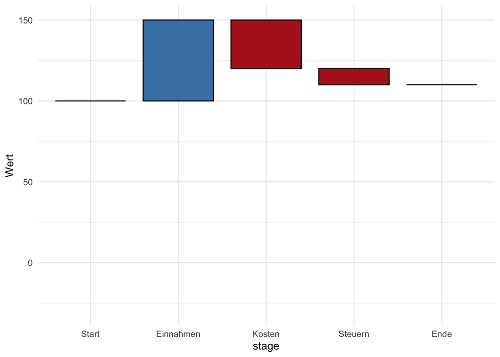

```r
waterfall_data <- data.frame(
  stage = factor(c("Start", "Einnahmen", "Kosten", "Steuern", "Ende"),
                 levels = c("Start", "Einnahmen", "Kosten", "Steuern", "Ende")),
  value = c(0, 50, -30, -10, 0),
  end = c(100, 150, 120, 110, 110),
  start = c(100, 100, 150, 120, 110),
  type = c("total", "in", "out", "out", "total"))

ggplot(waterfall_data, aes(x = stage, y = value, fill = type)) +
  geom_rect(aes(x = stage, xmin = as.numeric(stage) - 0.4,
                xmax = as.numeric(stage) + 0.4,
                ymin = pmin(start, end), ymax = pmax(start, end)),
            color = "black") +
  scale_fill_manual(values = c("in" = "steelblue", "out" = "firebrick",
                               "total" = "darkgrey"), guide = "none") +
  theme_minimal() + labs(y = "Wert")
```

### Heatmap

Farbintensität für Matrixwerte — gut für Muster, Cluster, Zeitreihen.

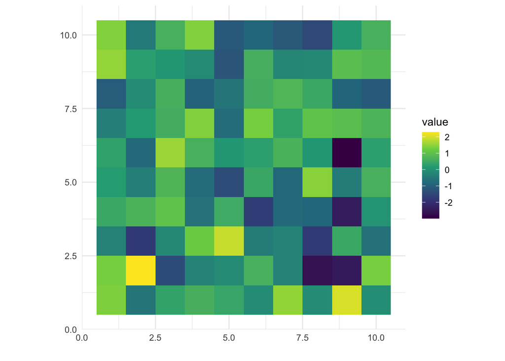

```r
set.seed(42)
n <- 10
heatmap_data <- expand.grid(x = 1:n, y = 1:n)
heatmap_data$value <- matrix(rnorm(n^2), n, n)[cbind(heatmap_data$x, heatmap_data$y)]

ggplot(heatmap_data, aes(x = x, y = y, fill = value)) +
  geom_tile() + scale_fill_viridis_c() + theme_minimal() +
  coord_equal() + labs(x = "", y = "")
```

### Treemap

Teil-Ganzes-Beziehungen: Die Fläche entspricht dem Wert.

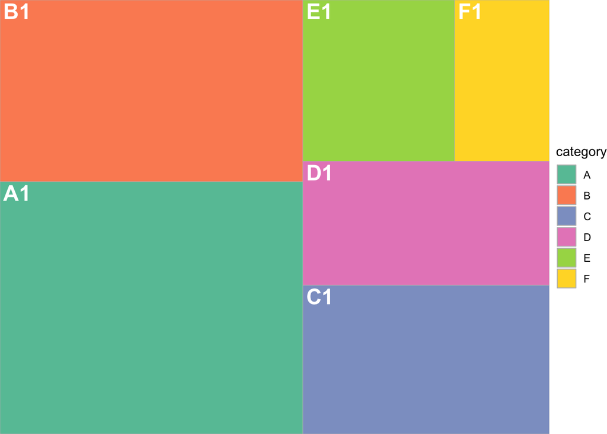

```r
library(treemapify)
treemap_data <- data.frame(
  category = c("A", "B", "C", "D", "E", "F"),
  subcategory = c("A1", "B1", "C1", "D1", "E1", "F1"),
  value = c(25, 18, 12, 10, 8, 5))

ggplot(treemap_data, aes(area = value, fill = category, label = subcategory)) +
  geom_treemap() +
  geom_treemap_text(color = "white", fontface = "bold") +
  scale_fill_brewer(palette = "Set2") + theme_void()
```

**Und zum Schluss:** Nein, Sie verwenden bitte keine Pie Charts! Menschen sind schlecht darin, Winkel zu vergleichen — ein (horizontaler) Bar Chart zeigt dieselbe Information fast immer besser.